# HW 7 - Single Variable Analysis- Guide

Jose Rico

April 25, 2020

# Table of Variables

| Original Variable | New Variable | Description |
| --- | --- | --- |
| RACE | race_c | subject’s race |
| BIO_SEX4 | gender | subject’s gender |
| H4DA11 | vigorous_activity | In the past 24 hours, have you participated in vigorous physical activity long enough to work up a sweat, get your heart thumping, or get out of breath? |
| H4MH23 | too_tired | (During the past seven days:) You felt that you were too tired to do things. |

## 1st Categorical (binary - 2 levels) `vigorous_activity`

**Numerical Summary Table**

vigorous_activity

n

percent

yes

2055

40.2%

no

3056

59.8%

Total

5111

**Bar Plot - Frequency of Levels**

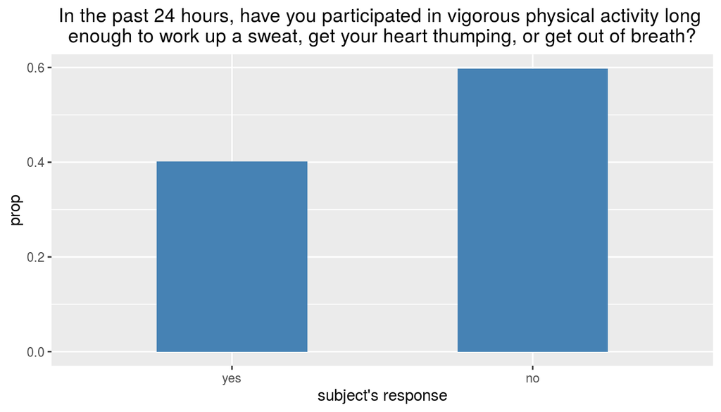

**Inference (CI and Test of Significance)**

```r
## inference CI and test of significance  (note: prop.test is for binary variables)
prop.test(~vigorous_activity == "no", data = vig_act)
```

```
##
##  1-sample proportions test with continuity correction
##
## data:  vig_act$vigorous_activity == "no"  [with success = TRUE]
## X-squared = 195.66, df = 1, p-value < 2.2e-16
## alternative hypothesis: true p is not equal to 0.5
## 95 percent confidence interval:
##  0.5843168 0.6113871
## sample estimates:
##        p
## 0.597926
```

**Summary of Analysis**

The participants in the **addhealth** study were asked, "*In the past 24 hours, have you participated in vigorous physical activity long enough to work up a sweat, get your heart thumping, or get out of breath?*

- 3056 out of 5111 (59.8%) of participants in the study answered “no”.
- Our sample proportion of 59.8% represents a statistically significant majority ($h_{0}=0.5$, p-value < 2.2e-16)
- 95% confidence interval for non-participation in vigorous activity is 58.4% to 61.1% (output from **mosaic**’s `prop.test` function)

## 2nd Categorical (mulitple levels) `too tired`

**Numerical Summary Table**

too_tired

n

percent

never or rarely

1764

34.5%

sometimes

2503

49.0%

alot of the time

615

12.0%

most of the time or all of the time

231

4.5%

Total

5113

**Bar Plot - Frequency of Levels**

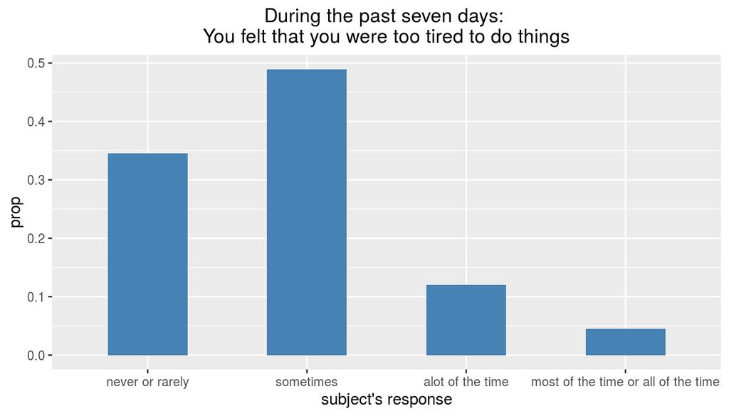

**Inference (CI and Test of Significance)**

```r
## inference CI and test of significance                    ##
## (note: prop.test needs you to choose a particular level) ##
prop.test(~too_tired == "never or rarely", data = tired)
```

```
##
##  1-sample proportions test with continuity correction
##
## data:  tired$too_tired == "never or rarely"  [with success = TRUE]
## X-squared = 490.72, df = 1, p-value < 2.2e-16
## alternative hypothesis: true p is not equal to 0.5
## 95 percent confidence interval:
##  0.3319969 0.3582434
## sample estimates:
##         p
## 0.3450029
```

```r
## the xchisq.test assesses the probability of obtaining ##
## a sample result if the levels were equaly likely.     ##
xchisq.test(~too_tired, data = tired)
```

```
##
##  Chi-squared test for given probabilities
##
## data:  x
## X-squared = 2560.2, df = 3, p-value < 2.2e-16
##
##   1764     2503      615      231
## (1278.25) (1278.25) (1278.25) (1278.25)
## [ 184.59] [1173.49] [ 344.14] [ 858.00]
## < 13.59> < 34.26> <-18.55> <-29.29>
##
## key:
##  observed
##  (expected)
##  [contribution to X-squared]
##  <Pearson residual>
```

**Summary of Analysis**

The participants in the **addhealth** study were asked, “*During the past seven days: You felt that you were too tired to do things*”

- 1764 out of 5113 (34.5%) of participants in the study answered “never or rarely”.
- Our sample proportion of 34.5% represents a statistically significant minority ($h_{0}=0.5$, p-value < 2.2e-16)
- 95% confidence interval for never or rarely felt too tired to do thing is 33.2% to 35.8% (output from **mosaic**’s `prop.test` function)
- A Chi-Squared test for equal likely levels yielded a test statistics of $\chi^2=2560$, with p-value < 2.2e-16, which allows us to conclude that the proportion for each response level are statistically significant (not equally likely). *In other words our sample’s distribution of results is not likely to occur by chance, if each response was equally likely*

[output not shown]

[output not shown]

[output not shown]

[output not shown]

[output not shown]